# Module 4: Extract and Analyze GIS Data

IALE 2015 R GIS Workshop

July 7, 2015

# Module 4.1

## Goals: Extract data for juniper across raster and vector layers at a set of points

Extract values from rasters and vectors at a set of points, and import point data for plant locations and rasters representing topographic data

## R Packages Needed

```r
library(sp)
library(rgdal)
library(raster)
library(fields)
```

## Set Your Working Directory

Change this to the correct path name on your machine

```r
setwd("~/Documents/IALE2015_StudentWorkshop/module4")
```

## Import Data

### Points

Load shapefile of *Juniperus osteosperma* point data that you created in module 1

```r
juos <- readOGR(dsn = "data/outdata", layer = "juos_pts_wgs84")
```

### Rasters

Load rasters for elevation, slope and aspect

```r
elev1k.wgs <- raster("data/elev_1k_wgs.img")
slp1k.wgs <- raster("data/slp_1k_wgs.img")
asp1k.wgs <- raster("data/asp_1k_wgs.img")
```

Combine rasters into single object. Earlier, you used RasterStacks. This time, let’s use a RasterBrick. They are very similar, but RasterBricks can be faster for computation. RasterStacks can access layers without keeping them all in memory, so that can be an advantage, too. It just depends on your needs.

```r
topo1k.wgs <- brick(elev1k.wgs, slp1k.wgs, asp1k.wgs)
```

Take a look at the brick.

```r
topo1k.wgs
```

```
## class       : RasterBrick
## dimensions  : 6692, 8778, 58742376, 3  (nrow, ncol, ncell, nlayers)
## resolution  : 0.008333333, 0.008333333  (x, y)
## extent      : -164.0992, -90.9492, 10.69607, 66.46274  (xmin, xmax, ymin, ymax)
## coord. ref. : +proj=longlat +datum=WGS84 +no_defs +ellps=WGS84 +towgs84=0,0,0
## data source : /private/var/folders/rd/lhhwh9016wq8fp1whhhpsxrw0000gr/T/R_raster_kjj/2015-07-15_145716_43883_78887.grd
## names       : elev_1k_wgs, slp_1k_wgs, asp_1k_wgs
## min values  :        -121,          0,         -1
## max values  :  4362.00000,   42.51611,  359.98398
```

Shorten the names of the layers in the brick.

```r
names(topo1k.wgs) <- c("elev", "slp", "asp")
topo1k.wgs
```

```
## class       : RasterBrick
## dimensions  : 6692, 8778, 58742376, 3  (nrow, ncol, ncell, nlayers)
## resolution  : 0.008333333, 0.008333333  (x, y)
## extent      : -164.0992, -90.9492, 10.69607, 66.46274  (xmin, xmax, ymin, ymax)
## coord. ref. : +proj=longlat +datum=WGS84 +no_defs +ellps=WGS84 +towgs84=0,0,0
## data source : /private/var/folders/rd/lhhwh9016wq8fp1whhhpsxrw0000gr/T/R_raster_kjj/2015-07-15_145716_43883_78887.grd
## names       :       elev,        slp,        asp
## min values  :       -121,          0,         -1
## max values  : 4362.00000,   42.51611,  359.98398
```

### Vectors

Load shapefile for soil

```r
soil <- readOGR(dsn = "data", layer = "soils")
```

Take a look at what kinds of data are in the `soil` object

```r
summary(soil)
```

```
## Object of class SpatialPolygonsDataFrame
## Coordinates:
##          min        max
## x -115.85295 -104.67795
## y   33.93571   43.25238
## Is projected: FALSE
## proj4string :
## [+proj=longlat +datum=WGS84 +no_defs +ellps=WGS84 +towgs84=0,0,0]
## Data attributes:
##      mukey             taxorder       taxsuborde           taxgrtgrou
##  657964 : 233   Mollisols  :1921   Orthents: 890   Torriorthents: 800
##  670492 :  65   Aridisols  :1757   Xerolls : 752   Haplocalcids : 633
##  659703 :  62   Entisols   :1255   Calcids : 724   Argiustolls  : 416
##  674637 :  57   Alfisols   : 603   Argids  : 693   Haplargids   : 392
##  659705 :  51   Inceptisols: 400   Ustolls : 597   Argixerolls  : 324
##  670465 :  41   (Other)    :  37   (Other) :2317   (Other)      :3398
##  (Other):6212   NA's       : 748   NA's    : 748   NA's         : 758
##                       taxsubgrp        subord         grtgrp
##  Ustic Haplargids          : 227   Ust    :1065   Hap    :2422
##  Lithic Xeric Torriorthents: 177   Ort    : 890   Arg    :1105
##  Ustic Calciargids         : 175   Cry    : 797   Tor    :1073
##  Ustic Torriorthents       : 167   Xer    : 793   non    : 758
##  Typic Torriorthents       : 166   non    : 758   Cal    : 471
##  (Other)                   :5024   Cal    : 724   Glo    : 149
##  NA's                      : 785   (Other):1694   (Other): 743
##     c_order       c_sbord        c_ggrp          phmin
##  Min.   :100   Min.   :100   Min.   :100.0   Min.   :  0.0
##  1st Qu.:103   1st Qu.:104   1st Qu.:103.0   1st Qu.:560.0
##  Median :104   Median :107   Median :120.0   Median :660.0
##  Mean   :104   Mean   :112   Mean   :115.6   Mean   :608.8
##  3rd Qu.:107   3rd Qu.:125   3rd Qu.:120.0   3rd Qu.:660.0
##  Max.   :110   Max.   :127   Max.   :141.0   Max.   :840.0
##
##      phave           phmax          frag3to10         sieveno4
##  Min.   :  0.0   Min.   :   0.0   Min.   : 0.000   Min.   :  0.00
##  1st Qu.:718.0   1st Qu.: 840.0   1st Qu.: 2.000   1st Qu.: 66.00
##  Median :781.0   Median : 900.0   Median : 7.000   Median : 78.00
##  Mean   :740.2   Mean   : 851.2   Mean   : 9.964   Mean   : 75.26
##  3rd Qu.:819.0   3rd Qu.: 900.0   3rd Qu.:16.000   3rd Qu.: 91.00
##  Max.   :900.0   Max.   :1100.0   Max.   :48.000   Max.   :100.00
```

[output cut: 50 more lines]

```
##  917    :2821   17     : 674   na     :1203   mixed     :4854
##  2822   :1630   6      : 509   44     : 338   smectitic : 759
##  282    : 477   13     : 504   46     : 320   carbonatic: 502
##  9174   : 336   14     : 501   41     : 291   not used  : 245
##  900    : 198   12     : 418   43     : 263   paramicac :  49
##  (Other): 608   (Other):3464   39     : 238   (Other)   :  74
##  NA's   : 651   NA's   : 651   (Other):4068   NA's      : 238
##       calcereous
##  acid      :  21
##  calcareous:2983
##  euic      :   8
##  NA's      :3709
##
##
##
```

Load the polygon that bounds the Colorado Plateau. It will be useful for cropping and masking.

```r
cp.latlong <- readOGR(dsn = "data", layer = "COP_boundpoly_wgs84")
```

## Crop and Mask Data

### Rasters

Crop elevation raster to a bounding box that fits around the Colorado Plateau

```r
topo.bbox <- crop(topo1k.wgs, cp.latlong)
```

Mask elevation raster to include only data within the Colorado Plateau polygon. This may take a while.

```r
topo.cp <- mask(topo.bbox, cp.latlong)
```

### Vectors

In the case of vector data, you can still use the `crop` function. However, it does in one function what both `crop` + `mask` do for raster data.

```r
soil.cp <- crop(soil, cp.latlong)
```

## Visualize Rasters, Vectors and Points

Take a look at the rasters.

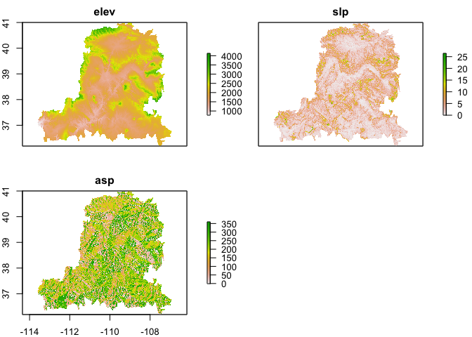

```r
plot(topo.cp)
```

Plot individual raster with points overlaid. Use `add = TRUE` or `add = T` to add points to the same plot.

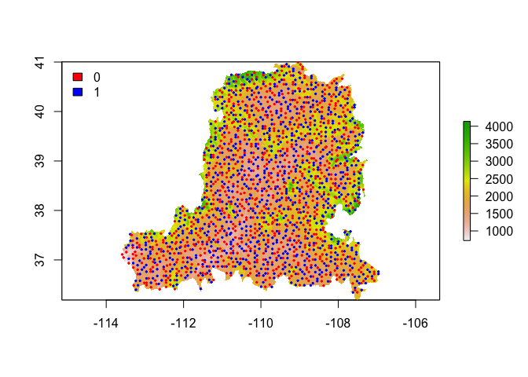

```r
plot(topo.cp$elev)
plot(juos, cex = 0.3, pch=19 ,col=c("red","blue"), add=T)
legend("topleft",fill=c("red","blue"), legend = c("0","1"), bty="n")
```

This will fill all the polygons in the soil object with orange.

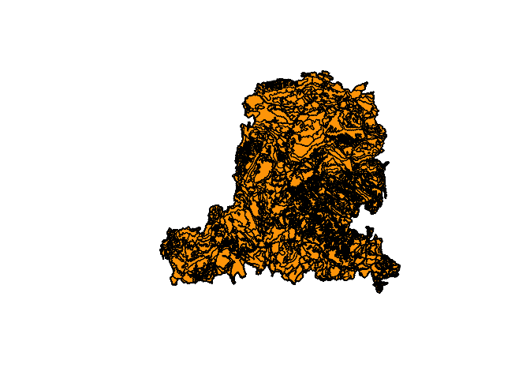

```r
plot(soil.cp, col="orange")
```

Alternatively, we can fill it with colors corresponding to data from one of the soil variables.

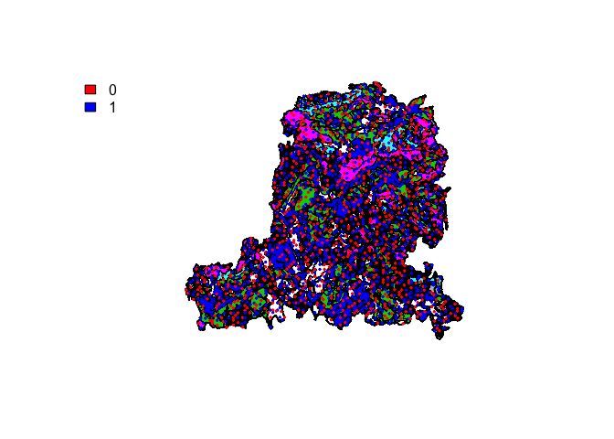

```r
plot(soil.cp, col=soil.cp$taxorder)
plot(juos, cex = 0.3, pch=19 ,col=c("red","blue"), add=T)
legend("topleft",fill=c("red","blue"), legend = c("0","1"), bty="n")
```

## Extract values

### Rasters

```r
topo.vals <- extract(topo.cp, juos, method="simple")
```

It’s always a good idea to check on your data, since you can’t see it. This shows us the number of values extracted from rasters. Then we can compare it with the number of points.

```r
dim(topo.vals)
```

```
## [1] 1798    3
```

```r
dim(coordinates(juos))
```

```
## [1] 1798    2
```

This shows the number of rows and columns of coordinate data, so we want it to be the same number of rows as the values above, and 2 columns wide, for x and y coordinates. Alternatively, you can just test if the number of rows are equal with the `==` operator.

```r
nrow(coordinates(juos)) == nrow(topo.vals)
```

```
## [1] TRUE
```

### Vectors

Even though `crop` and `extract` are from the raster package, they have been made to work on vector data, too.

```r
soil.vals <- extract(soil.cp, juos, method="simple")
```

Let’s look at the dimensions of the data frame we just created. Because the vector data represent many soil characteristics, it has created a data frame that contains many columns.

```r
dim(soil.vals)
```

```
## [1] 1798   46
```

## Combine extracted values into a data frame

```r
extract_juos <- data.frame(juos$coords.x1,
                      juos$coords.x2,
                      juos$juos,
                      topo.vals,
                      soil.vals)
```

Now take a look at the top end of our data frame.

```r
head(extract_juos)
```

```
##   juos.coords.x1 juos.coords.x2 juos.juos elev       slp       asp
## 1      -109.0390       40.99637         0   NA        NA        NA
## 2      -109.3372       40.95580         0 2415 3.2312350 214.86852
## 3      -108.9809       40.95033         0 2455 0.9591002 107.85032
## 4      -109.4567       40.91271         1 1872 4.7746687  28.80268
## 5      -109.3977       40.91184         1 1989 6.0288043 180.73264
## 6      -109.2789       40.91011         1 1737 0.8189415 247.79652
##   point.ID poly.ID  mukey  taxorder taxsuborde   taxgrtgrou
## 1        1    1059 676954 Mollisols    Cryolls  Argicryolls
## 2        2     703 674453 Aridisols    Calcids Haplocalcids
## 3        3    1059 676954 Mollisols    Cryolls  Argicryolls
## 4        4    1114 657964      <NA>       <NA>         <NA>
## 5        5     703 674453 Aridisols    Calcids Haplocalcids
## 6        6     703 674453 Aridisols    Calcids Haplocalcids
##            taxsubgrp subord grtgrp c_order c_sbord c_ggrp phmin phave
```

[output cut: 34 more lines]

The names of the columns are less than ideal. One way to give them better names is to write them into the data frame in the first place.

```r
extract_juos <- data.frame(X=juos$coords.x1,
                      Y=juos$coords.x2,
                      juos=juos$juos,
                      topo.vals,
                      soil.vals)
```

## Export data

Now export the data as a .csv file for storing and accessing.

```r
write.csv(extract_juos, "data/outdata/extract_juos.csv")
```

Take a look at the `.csv` file in MS Excel or another spreadsheet application. You’ll notice that the first column contains row numbers, which we probably don’t really want. So let’s find out how to get rid of those. Let’s use the quickest way to get help with functions (which I use very often).

```r
?write.csv
```

The documentation for `write.csv` will help you to figure out that `row.names=FALSE` will allow you to get rid of that first column, so let’s do that.

```r
write.csv(extract_juos, "data/outdata/extract_juos.csv", row.names=F)
```

Let’s export our other files. You can export the rasters into the same file, as long as you use a file type that supports multiple bands, like `.tif`.

```r
writeRaster(topo.cp, "data/outdata/topo_cp.grd", format="raster", overwrite=T)
```

Write soils data

```r
writeOGR(soil.cp, "data/outdata/soil", "soil", "ESRI Shapefile", overwrite=T)
```